# Optimal Treatment Analysis

## Outcome Variable

**Outcome Variable:** ever_stunted

## Predictor Variables

**Intervention Variable:** lag_WHZ_quart

**Adjustment Set:**

- arm
- sex
- W_mage
- meducyrs
- feducyrs
- single
- month
- brthmon
- delta_W_mage
- delta_meducyrs
- delta_feducyrs
- delta_single
- delta_month
- delta_brthmon

## Stratifying Variables

The analysis was stratified on these variable(s):

- agecat
- studyid
- country

## Data Summary

| agecat | studyid | country | lag_WHZ_quart | ever_stunted | n_cell | n |
| --- | --- | --- | --- | --- | --- | --- |
| 3-6 months | ki0047075b-MAL-ED | BANGLADESH | 1 | 0 | 43 | 207 |
| 3-6 months | ki0047075b-MAL-ED | BANGLADESH | 1 | 1 | 5 | 207 |
| 3-6 months | ki0047075b-MAL-ED | BANGLADESH | 2 | 0 | 78 | 207 |
| 3-6 months | ki0047075b-MAL-ED | BANGLADESH | 2 | 1 | 14 | 207 |
| 3-6 months | ki0047075b-MAL-ED | BANGLADESH | 3 | 0 | 51 | 207 |
| 3-6 months | ki0047075b-MAL-ED | BANGLADESH | 3 | 1 | 8 | 207 |
| 3-6 months | ki0047075b-MAL-ED | BANGLADESH | 4 | 0 | 7 | 207 |
| 3-6 months | ki0047075b-MAL-ED | BANGLADESH | 4 | 1 | 1 | 207 |
| 3-6 months | ki0047075b-MAL-ED | BRAZIL | 1 | 0 | 32 | 201 |
| 3-6 months | ki0047075b-MAL-ED | BRAZIL | 1 | 1 | 1 | 201 |
| 3-6 months | ki0047075b-MAL-ED | BRAZIL | 2 | 0 | 90 | 201 |
| 3-6 months | ki0047075b-MAL-ED | BRAZIL | 2 | 1 | 5 | 201 |
| 3-6 months | ki0047075b-MAL-ED | BRAZIL | 3 | 0 | 50 | 201 |
| 3-6 months | ki0047075b-MAL-ED | BRAZIL | 3 | 1 | 3 | 201 |
| 3-6 months | ki0047075b-MAL-ED | BRAZIL | 4 | 0 | 16 | 201 |
| 3-6 months | ki0047075b-MAL-ED | BRAZIL | 4 | 1 | 4 | 201 |
| 3-6 months | ki0047075b-MAL-ED | INDIA | 1 | 0 | 65 | 199 |
| 3-6 months | ki0047075b-MAL-ED | INDIA | 1 | 1 | 13 | 199 |
| 3-6 months | ki0047075b-MAL-ED | INDIA | 2 | 0 | 65 | 199 |
| 3-6 months | ki0047075b-MAL-ED | INDIA | 2 | 1 | 9 | 199 |
| 3-6 months | ki0047075b-MAL-ED | INDIA | 3 | 0 | 30 | 199 |
| 3-6 months | ki0047075b-MAL-ED | INDIA | 3 | 1 | 8 | 199 |
| 3-6 months | ki0047075b-MAL-ED | INDIA | 4 | 0 | 4 | 199 |
| 3-6 months | ki0047075b-MAL-ED | INDIA | 4 | 1 | 5 | 199 |
| 3-6 months | ki0047075b-MAL-ED | NEPAL | 1 | 0 | 43 | 210 |
| 3-6 months | ki0047075b-MAL-ED | NEPAL | 1 | 1 | 0 | 210 |
| 3-6 months | ki0047075b-MAL-ED | NEPAL | 2 | 0 | 80 | 210 |
| 3-6 months | ki0047075b-MAL-ED | NEPAL | 2 | 1 | 2 | 210 |
| 3-6 months | ki0047075b-MAL-ED | NEPAL | 3 | 0 | 68 | 210 |
| 3-6 months | ki0047075b-MAL-ED | NEPAL | 3 | 1 | 3 | 210 |

[output cut: 882 more lines]

The following strata were considered:

- agecat: 12-15 months, studyid: ki0047075b-MAL-ED, country: BANGLADESH
- agecat: 12-15 months, studyid: ki0047075b-MAL-ED, country: BRAZIL
- agecat: 12-15 months, studyid: ki0047075b-MAL-ED, country: INDIA
- agecat: 12-15 months, studyid: ki0047075b-MAL-ED, country: NEPAL
- agecat: 12-15 months, studyid: ki0047075b-MAL-ED, country: PERU
- agecat: 12-15 months, studyid: ki0047075b-MAL-ED, country: SOUTH AFRICA
- agecat: 12-15 months, studyid: ki0047075b-MAL-ED, country: TANZANIA, UNITED REPUBLIC OF
- agecat: 12-15 months, studyid: ki1000108-CMC-V-BCS-2002, country: INDIA
- agecat: 12-15 months, studyid: ki1000108-IRC, country: INDIA
- agecat: 12-15 months, studyid: ki1000109-EE, country: PAKISTAN
- agecat: 12-15 months, studyid: ki1017093b-PROVIDE, country: BANGLADESH
- agecat: 12-15 months, studyid: ki1066203-TanzaniaChild2, country: TANZANIA, UNITED REPUBLIC OF
- agecat: 12-15 months, studyid: ki1101329-Keneba, country: GAMBIA
- agecat: 12-15 months, studyid: ki1112895-Guatemala BSC, country: GUATEMALA
- agecat: 12-15 months, studyid: ki1113344-GMS-Nepal, country: NEPAL
- agecat: 12-15 months, studyid: ki1114097-CMIN, country: BANGLADESH
- agecat: 12-15 months, studyid: ki1114097-CMIN, country: PERU
- agecat: 15-18 months, studyid: ki0047075b-MAL-ED, country: BANGLADESH
- agecat: 15-18 months, studyid: ki0047075b-MAL-ED, country: BRAZIL
- agecat: 15-18 months, studyid: ki0047075b-MAL-ED, country: INDIA
- agecat: 15-18 months, studyid: ki0047075b-MAL-ED, country: NEPAL
- agecat: 15-18 months, studyid: ki0047075b-MAL-ED, country: PERU
- agecat: 15-18 months, studyid: ki0047075b-MAL-ED, country: SOUTH AFRICA
- agecat: 15-18 months, studyid: ki0047075b-MAL-ED, country: TANZANIA, UNITED REPUBLIC OF
- agecat: 15-18 months, studyid: ki1000108-CMC-V-BCS-2002, country: INDIA
- agecat: 15-18 months, studyid: ki1000108-IRC, country: INDIA
- agecat: 15-18 months, studyid: ki1000109-EE, country: PAKISTAN
- agecat: 15-18 months, studyid: ki1017093b-PROVIDE, country: BANGLADESH
- agecat: 15-18 months, studyid: ki1066203-TanzaniaChild2, country: TANZANIA, UNITED REPUBLIC OF
- agecat: 15-18 months, studyid: ki1101329-Keneba, country: GAMBIA
- agecat: 15-18 months, studyid: ki1112895-Guatemala BSC, country: GUATEMALA
- agecat: 15-18 months, studyid: ki1113344-GMS-Nepal, country: NEPAL
- agecat: 15-18 months, studyid: ki1114097-CMIN, country: BANGLADESH
- agecat: 15-18 months, studyid: ki1114097-CMIN, country: PERU
- agecat: 18-21 months, studyid: ki0047075b-MAL-ED, country: BANGLADESH
- agecat: 18-21 months, studyid: ki0047075b-MAL-ED, country: BRAZIL
- agecat: 18-21 months, studyid: ki0047075b-MAL-ED, country: INDIA
- agecat: 18-21 months, studyid: ki0047075b-MAL-ED, country: NEPAL
- agecat: 18-21 months, studyid: ki0047075b-MAL-ED, country: PERU
- agecat: 18-21 months, studyid: ki0047075b-MAL-ED, country: SOUTH AFRICA
- agecat: 18-21 months, studyid: ki0047075b-MAL-ED, country: TANZANIA, UNITED REPUBLIC OF
- agecat: 18-21 months, studyid: ki1000108-CMC-V-BCS-2002, country: INDIA
- agecat: 18-21 months, studyid: ki1000108-IRC, country: INDIA
- agecat: 18-21 months, studyid: ki1000109-EE, country: PAKISTAN
- agecat: 18-21 months, studyid: ki1017093b-PROVIDE, country: BANGLADESH
- agecat: 18-21 months, studyid: ki1066203-TanzaniaChild2, country: TANZANIA, UNITED REPUBLIC OF
- agecat: 18-21 months, studyid: ki1101329-Keneba, country: GAMBIA
- agecat: 18-21 months, studyid: ki1113344-GMS-Nepal, country: NEPAL
- agecat: 18-21 months, studyid: ki1114097-CMIN, country: BANGLADESH
- agecat: 18-21 months, studyid: ki1114097-CMIN, country: PERU
- agecat: 21-24 months, studyid: ki0047075b-MAL-ED, country: BANGLADESH
- agecat: 21-24 months, studyid: ki0047075b-MAL-ED, country: BRAZIL
- agecat: 21-24 months, studyid: ki0047075b-MAL-ED, country: INDIA
- agecat: 21-24 months, studyid: ki0047075b-MAL-ED, country: NEPAL
- agecat: 21-24 months, studyid: ki0047075b-MAL-ED, country: PERU
- agecat: 21-24 months, studyid: ki0047075b-MAL-ED, country: SOUTH AFRICA
- agecat: 21-24 months, studyid: ki0047075b-MAL-ED, country: TANZANIA, UNITED REPUBLIC OF
- agecat: 21-24 months, studyid: ki1000108-CMC-V-BCS-2002, country: INDIA
- agecat: 21-24 months, studyid: ki1000108-IRC, country: INDIA
- agecat: 21-24 months, studyid: ki1017093b-PROVIDE, country: BANGLADESH
- agecat: 21-24 months, studyid: ki1066203-TanzaniaChild2, country: TANZANIA, UNITED REPUBLIC OF
- agecat: 21-24 months, studyid: ki1101329-Keneba, country: GAMBIA
- agecat: 21-24 months, studyid: ki1113344-GMS-Nepal, country: NEPAL
- agecat: 21-24 months, studyid: ki1114097-CMIN, country: BANGLADESH
- agecat: 21-24 months, studyid: ki1114097-CMIN, country: PERU
- agecat: 3-6 months, studyid: ki0047075b-MAL-ED, country: BANGLADESH
- agecat: 3-6 months, studyid: ki0047075b-MAL-ED, country: BRAZIL
- agecat: 3-6 months, studyid: ki0047075b-MAL-ED, country: INDIA
- agecat: 3-6 months, studyid: ki0047075b-MAL-ED, country: NEPAL
- agecat: 3-6 months, studyid: ki0047075b-MAL-ED, country: PERU
- agecat: 3-6 months, studyid: ki0047075b-MAL-ED, country: SOUTH AFRICA
- agecat: 3-6 months, studyid: ki0047075b-MAL-ED, country: TANZANIA, UNITED REPUBLIC OF
- agecat: 3-6 months, studyid: ki1000108-CMC-V-BCS-2002, country: INDIA
- agecat: 3-6 months, studyid: ki1000108-IRC, country: INDIA
- agecat: 3-6 months, studyid: ki1000109-EE, country: PAKISTAN
- agecat: 3-6 months, studyid: ki1017093b-PROVIDE, country: BANGLADESH
- agecat: 3-6 months, studyid: ki1066203-TanzaniaChild2, country: TANZANIA, UNITED REPUBLIC OF
- agecat: 3-6 months, studyid: ki1101329-Keneba, country: GAMBIA
- agecat: 3-6 months, studyid: ki1112895-Guatemala BSC, country: GUATEMALA
- agecat: 3-6 months, studyid: ki1114097-CMIN, country: BANGLADESH
- agecat: 3-6 months, studyid: ki1114097-CMIN, country: PERU
- agecat: 6-9 months, studyid: ki0047075b-MAL-ED, country: BANGLADESH
- agecat: 6-9 months, studyid: ki0047075b-MAL-ED, country: BRAZIL
- agecat: 6-9 months, studyid: ki0047075b-MAL-ED, country: INDIA
- agecat: 6-9 months, studyid: ki0047075b-MAL-ED, country: NEPAL
- agecat: 6-9 months, studyid: ki0047075b-MAL-ED, country: PERU
- agecat: 6-9 months, studyid: ki0047075b-MAL-ED, country: SOUTH AFRICA
- agecat: 6-9 months, studyid: ki0047075b-MAL-ED, country: TANZANIA, UNITED REPUBLIC OF
- agecat: 6-9 months, studyid: ki1000108-CMC-V-BCS-2002, country: INDIA
- agecat: 6-9 months, studyid: ki1000108-IRC, country: INDIA
- agecat: 6-9 months, studyid: ki1000109-EE, country: PAKISTAN
- agecat: 6-9 months, studyid: ki1017093b-PROVIDE, country: BANGLADESH
- agecat: 6-9 months, studyid: ki1066203-TanzaniaChild2, country: TANZANIA, UNITED REPUBLIC OF
- agecat: 6-9 months, studyid: ki1101329-Keneba, country: GAMBIA
- agecat: 6-9 months, studyid: ki1112895-Guatemala BSC, country: GUATEMALA
- agecat: 6-9 months, studyid: ki1114097-CMIN, country: BANGLADESH
- agecat: 6-9 months, studyid: ki1114097-CMIN, country: PERU
- agecat: 9-12 months, studyid: ki0047075b-MAL-ED, country: BANGLADESH
- agecat: 9-12 months, studyid: ki0047075b-MAL-ED, country: BRAZIL
- agecat: 9-12 months, studyid: ki0047075b-MAL-ED, country: INDIA
- agecat: 9-12 months, studyid: ki0047075b-MAL-ED, country: NEPAL
- agecat: 9-12 months, studyid: ki0047075b-MAL-ED, country: PERU
- agecat: 9-12 months, studyid: ki0047075b-MAL-ED, country: SOUTH AFRICA
- agecat: 9-12 months, studyid: ki0047075b-MAL-ED, country: TANZANIA, UNITED REPUBLIC OF
- agecat: 9-12 months, studyid: ki1000108-CMC-V-BCS-2002, country: INDIA
- agecat: 9-12 months, studyid: ki1000108-IRC, country: INDIA
- agecat: 9-12 months, studyid: ki1000109-EE, country: PAKISTAN
- agecat: 9-12 months, studyid: ki1017093b-PROVIDE, country: BANGLADESH
- agecat: 9-12 months, studyid: ki1066203-TanzaniaChild2, country: TANZANIA, UNITED REPUBLIC OF
- agecat: 9-12 months, studyid: ki1101329-Keneba, country: GAMBIA
- agecat: 9-12 months, studyid: ki1112895-Guatemala BSC, country: GUATEMALA
- agecat: 9-12 months, studyid: ki1113344-GMS-Nepal, country: NEPAL
- agecat: 9-12 months, studyid: ki1114097-CMIN, country: BANGLADESH
- agecat: 9-12 months, studyid: ki1114097-CMIN, country: PERU

### Dropped Strata

Some strata were dropped due to rare outcomes:

- agecat: 3-6 months, studyid: ki0047075b-MAL-ED, country: BANGLADESH
- agecat: 3-6 months, studyid: ki0047075b-MAL-ED, country: BRAZIL
- agecat: 3-6 months, studyid: ki0047075b-MAL-ED, country: INDIA
- agecat: 3-6 months, studyid: ki0047075b-MAL-ED, country: NEPAL
- agecat: 3-6 months, studyid: ki0047075b-MAL-ED, country: PERU
- agecat: 3-6 months, studyid: ki0047075b-MAL-ED, country: SOUTH AFRICA
- agecat: 3-6 months, studyid: ki0047075b-MAL-ED, country: TANZANIA, UNITED REPUBLIC OF
- agecat: 3-6 months, studyid: ki1000108-CMC-V-BCS-2002, country: INDIA
- agecat: 3-6 months, studyid: ki1000108-IRC, country: INDIA
- agecat: 3-6 months, studyid: ki1000109-EE, country: PAKISTAN
- agecat: 3-6 months, studyid: ki1112895-Guatemala BSC, country: GUATEMALA
- agecat: 3-6 months, studyid: ki1114097-CMIN, country: BANGLADESH
- agecat: 6-9 months, studyid: ki0047075b-MAL-ED, country: BANGLADESH
- agecat: 6-9 months, studyid: ki0047075b-MAL-ED, country: BRAZIL
- agecat: 6-9 months, studyid: ki0047075b-MAL-ED, country: INDIA
- agecat: 6-9 months, studyid: ki0047075b-MAL-ED, country: NEPAL
- agecat: 6-9 months, studyid: ki1000108-CMC-V-BCS-2002, country: INDIA
- agecat: 6-9 months, studyid: ki1000108-IRC, country: INDIA
- agecat: 6-9 months, studyid: ki1000109-EE, country: PAKISTAN
- agecat: 6-9 months, studyid: ki1017093b-PROVIDE, country: BANGLADESH
- agecat: 6-9 months, studyid: ki1114097-CMIN, country: BANGLADESH
- agecat: 9-12 months, studyid: ki0047075b-MAL-ED, country: BANGLADESH
- agecat: 9-12 months, studyid: ki0047075b-MAL-ED, country: BRAZIL
- agecat: 9-12 months, studyid: ki0047075b-MAL-ED, country: INDIA
- agecat: 9-12 months, studyid: ki0047075b-MAL-ED, country: NEPAL
- agecat: 9-12 months, studyid: ki0047075b-MAL-ED, country: PERU
- agecat: 9-12 months, studyid: ki0047075b-MAL-ED, country: SOUTH AFRICA
- agecat: 9-12 months, studyid: ki1000108-CMC-V-BCS-2002, country: INDIA
- agecat: 9-12 months, studyid: ki1000108-IRC, country: INDIA
- agecat: 9-12 months, studyid: ki1000109-EE, country: PAKISTAN
- agecat: 9-12 months, studyid: ki1017093b-PROVIDE, country: BANGLADESH
- agecat: 9-12 months, studyid: ki1101329-Keneba, country: GAMBIA
- agecat: 9-12 months, studyid: ki1112895-Guatemala BSC, country: GUATEMALA
- agecat: 9-12 months, studyid: ki1113344-GMS-Nepal, country: NEPAL
- agecat: 9-12 months, studyid: ki1114097-CMIN, country: BANGLADESH
- agecat: 12-15 months, studyid: ki0047075b-MAL-ED, country: BANGLADESH
- agecat: 12-15 months, studyid: ki0047075b-MAL-ED, country: BRAZIL
- agecat: 12-15 months, studyid: ki0047075b-MAL-ED, country: INDIA
- agecat: 12-15 months, studyid: ki0047075b-MAL-ED, country: NEPAL
- agecat: 12-15 months, studyid: ki0047075b-MAL-ED, country: PERU
- agecat: 12-15 months, studyid: ki0047075b-MAL-ED, country: SOUTH AFRICA
- agecat: 12-15 months, studyid: ki1000108-CMC-V-BCS-2002, country: INDIA
- agecat: 12-15 months, studyid: ki1000108-IRC, country: INDIA
- agecat: 12-15 months, studyid: ki1000109-EE, country: PAKISTAN
- agecat: 12-15 months, studyid: ki1017093b-PROVIDE, country: BANGLADESH
- agecat: 12-15 months, studyid: ki1112895-Guatemala BSC, country: GUATEMALA
- agecat: 12-15 months, studyid: ki1113344-GMS-Nepal, country: NEPAL
- agecat: 12-15 months, studyid: ki1114097-CMIN, country: BANGLADESH
- agecat: 15-18 months, studyid: ki0047075b-MAL-ED, country: BANGLADESH
- agecat: 15-18 months, studyid: ki0047075b-MAL-ED, country: BRAZIL
- agecat: 15-18 months, studyid: ki0047075b-MAL-ED, country: INDIA
- agecat: 15-18 months, studyid: ki0047075b-MAL-ED, country: NEPAL
- agecat: 15-18 months, studyid: ki0047075b-MAL-ED, country: PERU
- agecat: 15-18 months, studyid: ki0047075b-MAL-ED, country: SOUTH AFRICA
- agecat: 15-18 months, studyid: ki0047075b-MAL-ED, country: TANZANIA, UNITED REPUBLIC OF
- agecat: 15-18 months, studyid: ki1000108-CMC-V-BCS-2002, country: INDIA
- agecat: 15-18 months, studyid: ki1000108-IRC, country: INDIA
- agecat: 15-18 months, studyid: ki1000109-EE, country: PAKISTAN
- agecat: 15-18 months, studyid: ki1017093b-PROVIDE, country: BANGLADESH
- agecat: 15-18 months, studyid: ki1101329-Keneba, country: GAMBIA
- agecat: 15-18 months, studyid: ki1112895-Guatemala BSC, country: GUATEMALA
- agecat: 15-18 months, studyid: ki1113344-GMS-Nepal, country: NEPAL
- agecat: 15-18 months, studyid: ki1114097-CMIN, country: BANGLADESH
- agecat: 15-18 months, studyid: ki1114097-CMIN, country: PERU
- agecat: 18-21 months, studyid: ki0047075b-MAL-ED, country: BANGLADESH
- agecat: 18-21 months, studyid: ki0047075b-MAL-ED, country: BRAZIL
- agecat: 18-21 months, studyid: ki0047075b-MAL-ED, country: INDIA
- agecat: 18-21 months, studyid: ki0047075b-MAL-ED, country: NEPAL
- agecat: 18-21 months, studyid: ki0047075b-MAL-ED, country: PERU
- agecat: 18-21 months, studyid: ki0047075b-MAL-ED, country: SOUTH AFRICA
- agecat: 18-21 months, studyid: ki0047075b-MAL-ED, country: TANZANIA, UNITED REPUBLIC OF
- agecat: 18-21 months, studyid: ki1000108-CMC-V-BCS-2002, country: INDIA
- agecat: 18-21 months, studyid: ki1000108-IRC, country: INDIA
- agecat: 18-21 months, studyid: ki1000109-EE, country: PAKISTAN
- agecat: 18-21 months, studyid: ki1017093b-PROVIDE, country: BANGLADESH
- agecat: 18-21 months, studyid: ki1066203-TanzaniaChild2, country: TANZANIA, UNITED REPUBLIC OF
- agecat: 18-21 months, studyid: ki1101329-Keneba, country: GAMBIA
- agecat: 18-21 months, studyid: ki1113344-GMS-Nepal, country: NEPAL
- agecat: 18-21 months, studyid: ki1114097-CMIN, country: BANGLADESH
- agecat: 18-21 months, studyid: ki1114097-CMIN, country: PERU
- agecat: 21-24 months, studyid: ki0047075b-MAL-ED, country: BANGLADESH
- agecat: 21-24 months, studyid: ki0047075b-MAL-ED, country: BRAZIL
- agecat: 21-24 months, studyid: ki0047075b-MAL-ED, country: INDIA
- agecat: 21-24 months, studyid: ki0047075b-MAL-ED, country: NEPAL
- agecat: 21-24 months, studyid: ki0047075b-MAL-ED, country: PERU
- agecat: 21-24 months, studyid: ki0047075b-MAL-ED, country: SOUTH AFRICA
- agecat: 21-24 months, studyid: ki0047075b-MAL-ED, country: TANZANIA, UNITED REPUBLIC OF
- agecat: 21-24 months, studyid: ki1000108-CMC-V-BCS-2002, country: INDIA
- agecat: 21-24 months, studyid: ki1000108-IRC, country: INDIA
- agecat: 21-24 months, studyid: ki1017093b-PROVIDE, country: BANGLADESH
- agecat: 21-24 months, studyid: ki1066203-TanzaniaChild2, country: TANZANIA, UNITED REPUBLIC OF
- agecat: 21-24 months, studyid: ki1101329-Keneba, country: GAMBIA
- agecat: 21-24 months, studyid: ki1113344-GMS-Nepal, country: NEPAL
- agecat: 21-24 months, studyid: ki1114097-CMIN, country: BANGLADESH
- agecat: 21-24 months, studyid: ki1114097-CMIN, country: PERU

## Methods Detail

We’re interested in the causal parameters $E[Y_a]$ for all values of $a \in \mathcal{A}$. These parameters represent the mean outcome if, possibly contrary to fact, we intervened to set all units to have $A=a$. Under the randomization and positivity assumptions, these are identified by the statistical parameters $\psi_a=E_W[E_{Y|A,W}(Y|A=a,W)]$. In addition, we’re interested in the mean of $Y$, $E[Y]$ under no intervention (the observed mean). We will estimate these parameters by using SuperLearner to fit the relevant likelihood factors – $E_{Y|A,W}(Y|A=a,W)$ and $p(A=a|W)$, and then updating our likelihood fit using a joint TMLE.

For unadjusted analyses ($W=\{\}$), initial likelihoods were estimated using Lrnr_glm to estimate the simple $E(Y|A)$ and Lrnr_mean to estimate $p(A)$. For adjusted analyses, a small library containing Lrnr_glmnet, Lrnr_xgboost, and Lrnr_mean was used.

Having estimated these parameters, we will then use the delta method to estimate relative risks and attributable risks relative to a prespecified baseline level of $A$.

# Results Detail

## Results Plots

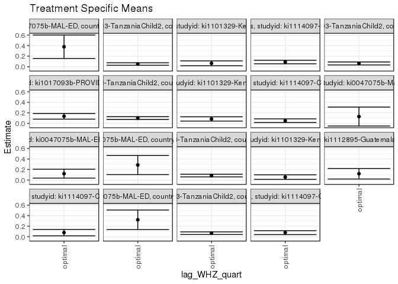

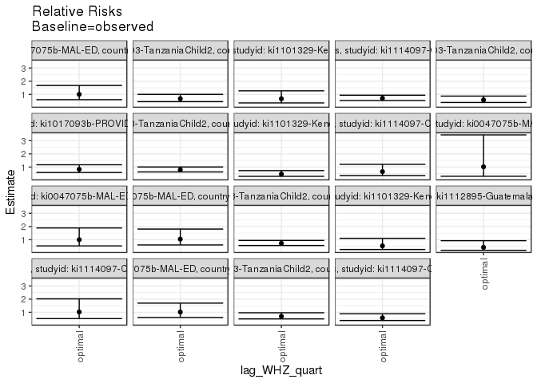

## Results Table

### Parameter: TSM

| agecat | studyid | country | intervention_level | baseline_level | estimate | ci_lower | ci_upper |
| --- | --- | --- | --- | --- | --- | --- | --- |
| 3-6 months | ki1017093b-PROVIDE | BANGLADESH | optimal | NA | 0.1341548 | 0.0805448 | 0.1877648 |
| 3-6 months | ki1066203-TanzaniaChild2 | TANZANIA, UNITED REPUBLIC OF | optimal | NA | 0.1009940 | 0.0747562 | 0.1272319 |
| 3-6 months | ki1101329-Keneba | GAMBIA | optimal | NA | 0.0842208 | 0.0436236 | 0.1248179 |
| 3-6 months | ki1114097-CMIN | PERU | optimal | NA | 0.0509012 | 0.0162582 | 0.0855441 |
| 6-9 months | ki0047075b-MAL-ED | PERU | optimal | NA | 0.1294240 | -0.0502144 | 0.3090623 |
| 6-9 months | ki0047075b-MAL-ED | SOUTH AFRICA | optimal | NA | 0.1212571 | 0.0366698 | 0.2058444 |
| 6-9 months | ki0047075b-MAL-ED | TANZANIA, UNITED REPUBLIC OF | optimal | NA | 0.2857353 | 0.1036758 | 0.4677947 |
| 6-9 months | ki1066203-TanzaniaChild2 | TANZANIA, UNITED REPUBLIC OF | optimal | NA | 0.0854098 | 0.0601892 | 0.1106305 |
| 6-9 months | ki1101329-Keneba | GAMBIA | optimal | NA | 0.0561015 | 0.0128637 | 0.0993393 |
| 6-9 months | ki1112895-Guatemala BSC | GUATEMALA | optimal | NA | 0.1200787 | 0.0196316 | 0.2205258 |
| 6-9 months | ki1114097-CMIN | PERU | optimal | NA | 0.0778727 | 0.0173544 | 0.1383911 |
| 9-12 months | ki0047075b-MAL-ED | TANZANIA, UNITED REPUBLIC OF | optimal | NA | 0.3218121 | 0.1365008 | 0.5071235 |
| 9-12 months | ki1066203-TanzaniaChild2 | TANZANIA, UNITED REPUBLIC OF | optimal | NA | 0.0670749 | 0.0420304 | 0.0921193 |
| 9-12 months | ki1114097-CMIN | PERU | optimal | NA | 0.0778617 | 0.0402815 | 0.1154419 |
| 12-15 months | ki0047075b-MAL-ED | TANZANIA, UNITED REPUBLIC OF | optimal | NA | 0.3786699 | 0.1559796 | 0.6013603 |
| 12-15 months | ki1066203-TanzaniaChild2 | TANZANIA, UNITED REPUBLIC OF | optimal | NA | 0.0508057 | 0.0273097 | 0.0743017 |
| 12-15 months | ki1101329-Keneba | GAMBIA | optimal | NA | 0.0644896 | 0.0188147 | 0.1101645 |
| 12-15 months | ki1114097-CMIN | PERU | optimal | NA | 0.0883514 | 0.0547999 | 0.1219029 |
| 15-18 months | ki1066203-TanzaniaChild2 | TANZANIA, UNITED REPUBLIC OF | optimal | NA | 0.0615903 | 0.0332358 | 0.0899448 |

### Parameter: E(Y)

| agecat | studyid | country | intervention_level | baseline_level | estimate | ci_lower | ci_upper |
| --- | --- | --- | --- | --- | --- | --- | --- |
| 3-6 months | ki1017093b-PROVIDE | BANGLADESH | observed | NA | 0.1615054 | 0.1302469 | 0.1927639 |
| 3-6 months | ki1066203-TanzaniaChild2 | TANZANIA, UNITED REPUBLIC OF | observed | NA | 0.1269999 | 0.1127034 | 0.1412964 |
| 3-6 months | ki1101329-Keneba | GAMBIA | observed | NA | 0.1811529 | 0.1517217 | 0.2105840 |
| 3-6 months | ki1114097-CMIN | PERU | observed | NA | 0.0781377 | 0.0562023 | 0.1000731 |
| 6-9 months | ki0047075b-MAL-ED | PERU | observed | NA | 0.1272718 | 0.0758233 | 0.1787204 |
| 6-9 months | ki0047075b-MAL-ED | SOUTH AFRICA | observed | NA | 0.1211804 | 0.0723749 | 0.1699860 |
| 6-9 months | ki0047075b-MAL-ED | TANZANIA, UNITED REPUBLIC OF | observed | NA | 0.2739243 | 0.2043903 | 0.3434584 |
| 6-9 months | ki1066203-TanzaniaChild2 | TANZANIA, UNITED REPUBLIC OF | observed | NA | 0.1175421 | 0.1021357 | 0.1329484 |
| 6-9 months | ki1101329-Keneba | GAMBIA | observed | NA | 0.1053461 | 0.0803582 | 0.1303339 |
| 6-9 months | ki1112895-Guatemala BSC | GUATEMALA | observed | NA | 0.2849655 | 0.2183572 | 0.3515738 |
| 6-9 months | ki1114097-CMIN | PERU | observed | NA | 0.0757160 | 0.0538319 | 0.0976002 |
| 9-12 months | ki0047075b-MAL-ED | TANZANIA, UNITED REPUBLIC OF | observed | NA | 0.3155525 | 0.2348521 | 0.3962529 |
| 9-12 months | ki1066203-TanzaniaChild2 | TANZANIA, UNITED REPUBLIC OF | observed | NA | 0.0964246 | 0.0802859 | 0.1125634 |
| 9-12 months | ki1114097-CMIN | PERU | observed | NA | 0.1338607 | 0.1045706 | 0.1631508 |
| 12-15 months | ki0047075b-MAL-ED | TANZANIA, UNITED REPUBLIC OF | observed | NA | 0.3773126 | 0.2773673 | 0.4772579 |
| 12-15 months | ki1066203-TanzaniaChild2 | TANZANIA, UNITED REPUBLIC OF | observed | NA | 0.0754993 | 0.0586665 | 0.0923321 |
| 12-15 months | ki1101329-Keneba | GAMBIA | observed | NA | 0.0960038 | 0.0669577 | 0.1250499 |
| 12-15 months | ki1114097-CMIN | PERU | observed | NA | 0.1244414 | 0.0939724 | 0.1549103 |
| 15-18 months | ki1066203-TanzaniaChild2 | TANZANIA, UNITED REPUBLIC OF | observed | NA | 0.1058456 | 0.0835189 | 0.1281723 |

### Parameter: RR

| agecat | studyid | country | intervention_level | baseline_level | estimate | ci_lower | ci_upper |
| --- | --- | --- | --- | --- | --- | --- | --- |
| 3-6 months | ki1017093b-PROVIDE | BANGLADESH | optimal | observed | 0.8306518 | 0.5878706 | 1.1736979 |
| 3-6 months | ki1066203-TanzaniaChild2 | TANZANIA, UNITED REPUBLIC OF | optimal | observed | 0.7952293 | 0.6292441 | 1.0049991 |
| 3-6 months | ki1101329-Keneba | GAMBIA | optimal | observed | 0.4649154 | 0.2966805 | 0.7285490 |
| 3-6 months | ki1114097-CMIN | PERU | optimal | observed | 0.6514293 | 0.3520811 | 1.2052906 |
| 6-9 months | ki0047075b-MAL-ED | PERU | optimal | observed | 1.0169097 | 0.3006367 | 3.4397173 |
| 6-9 months | ki0047075b-MAL-ED | SOUTH AFRICA | optimal | observed | 1.0006329 | 0.5299024 | 1.8895294 |
| 6-9 months | ki0047075b-MAL-ED | TANZANIA, UNITED REPUBLIC OF | optimal | observed | 1.0431175 | 0.6024598 | 1.8060858 |
| 6-9 months | ki1066203-TanzaniaChild2 | TANZANIA, UNITED REPUBLIC OF | optimal | observed | 0.7266318 | 0.5589381 | 0.9446373 |
| 6-9 months | ki1101329-Keneba | GAMBIA | optimal | observed | 0.5325448 | 0.2567281 | 1.1046859 |
| 6-9 months | ki1112895-Guatemala BSC | GUATEMALA | optimal | observed | 0.4213797 | 0.1918672 | 0.9254360 |
| 6-9 months | ki1114097-CMIN | PERU | optimal | observed | 1.0284845 | 0.5231409 | 2.0219797 |
| 9-12 months | ki0047075b-MAL-ED | TANZANIA, UNITED REPUBLIC OF | optimal | observed | 1.0198370 | 0.6129167 | 1.6969148 |
| 9-12 months | ki1066203-TanzaniaChild2 | TANZANIA, UNITED REPUBLIC OF | optimal | observed | 0.6956195 | 0.4998203 | 0.9681208 |
| 9-12 months | ki1114097-CMIN | PERU | optimal | observed | 0.5816624 | 0.3801564 | 0.8899787 |
| 12-15 months | ki0047075b-MAL-ED | TANZANIA, UNITED REPUBLIC OF | optimal | observed | 1.0035973 | 0.6009108 | 1.6761350 |
| 12-15 months | ki1066203-TanzaniaChild2 | TANZANIA, UNITED REPUBLIC OF | optimal | observed | 0.6729294 | 0.4503516 | 1.0055122 |
| 12-15 months | ki1101329-Keneba | GAMBIA | optimal | observed | 0.6717400 | 0.3552383 | 1.2702308 |
| 12-15 months | ki1114097-CMIN | PERU | optimal | observed | 0.7099843 | 0.5374121 | 0.9379723 |
| 15-18 months | ki1066203-TanzaniaChild2 | TANZANIA, UNITED REPUBLIC OF | optimal | observed | 0.5818885 | 0.3886175 | 0.8712790 |